# Molecular assays to reliably detect and quantify predation on a forest pest in bats faeces | Scientific Reports

# Molecular assays to reliably detect and quantify predation on a forest pest in bats faeces

- Unai Baroja,
- Inazio Garin,
- Nerea Vallejo,
- Amaia Caro,
- Carlos Ibáñez,
- …
- Andrea Basso &
- Urtzi Goiti

[*Scientific Reports*](https://www.nature.com/srep) **volume 12**, Article number: 2243 (2022) Cite this article

## Abstract

Targeted molecular methods such as conventional PCR (cPCR) and quantitative PCR (qPCR), combined with species-specific primers and probes, are widely applied for pest species detection. Besides, the potential of qPCR to quantify DNA in samples makes it an invaluable molecular tool to infer the predation levels on specific prey by analysing predators’ stools. Nevertheless, studies on the diet of bats failed to find any empirical relationship, and it remains to be evaluated. Thus, we developed and evaluated two species-specific PCR assays to detect and quantify DNA of a major forest pest, the pine processionary, *Thaumetopoea pityocampa,* in bats’ faeces. Further, we empirically compared a range of different known DNA concentrations (input) of the target species mixed with mocks and bat faecal samples against DNA abundances yielded by qPCR (output) for a quantitative assessment. Overall, cPCR showed a lower detection rate than qPCR, but augmenting the replicate effort from one to three replicates led to a greater increase in the detection rate of the cPCR (from 57 to 80%) than the qPCR (from 90 to 99%). The quantitative experiment results showed a highly significant correlation between the input and output DNA concentrations (t = 10.84, p < 0.001) with a mean slope value of 1.05, indicating the accuracy of our qPCR assay to estimate DNA abundance of *T. pityocampa* in bat faeces. The framework of this study can be taken as a model to design similar assays applicable to other species of interest, such as agricultural pests or insects of public health concern.

## Introduction

The pine processionary moth, *Thaumetopoea pityocampa*, is a significant forest pest of coniferous trees in the Western Palearctic. The larvae not only defoliate trees causing significant growth reduction and leading to severe economic losses<sup>1,2</sup>, but its urticating setae are also considered a risk to human and animal health<sup>3,4</sup>. The species is rapidly responding to climate change prolonging its active period and spreading northward<sup>5,6,7</sup>. Among its natural predators, insectivorous bats are common predators of adult moths<sup>8</sup>, with a vast array of bat species preying on *T. pityocampa*<sup>9</sup>. These bat species increase their hunting activity at pine stand edges where *T. pityocampa* swarms<sup>10</sup>. Some of these bat species have a broad foraging range<sup>11,12,13</sup>, reaching prey-abundant distant areas. During the breeding period, female bats increase their food intake imposed by pregnancy’s high energetic demands<sup>14</sup>, which coincides with the high resource availability period (e.g., the outbreak of *T. pityocampa*). In summary, these flying mammals may precisely track the abundance of *T. pityocampa* and other species of interest (e.g.<sup>15</sup>).

Current molecular techniques for identifying bat prey in diet studies are primarily based on the metabarcoding of prey DNA in faeces (e.g.<sup>16,17,18</sup>). The high throughput sequencing of thousands of PCR amplicons in parallel renders this technique a powerful tool to study animals’ diets with a high diversity of consumed taxa<sup>19,20</sup>. Nonetheless, specialised laboratory equipment and personnel are required, and the budget needed to process the data makes it impractical in many research settings. Moreover, metabarcoding brings an imbalanced amplification of the prey’s DNA attributed to the differential affinity of the primer sets across taxa, which can potentially lead to false-negative results of some prey<sup>21</sup>. Likewise, as most insectivorous bats have diverse diets, the large number of DNA sequences from multiple taxa binding to universal primers can potentially disguise the detection of some species of interest<sup>20,22,23</sup>. In that sense, although it is tempting to assume that prey DNA sequence proportions or read counts recovered from faecal samples are representative of predator’s diet proportions, digestion and amplification biases impair quantitative interpretations of the data, especially in samples containing many taxa<sup>24,25</sup>. Consequently, reliable results of metabarcoding restrict to the qualitative assessment of the species list in the faecal samples. Hence, whereby a single-species detection is aimed, metabarcoding may fail to reliably capture the target species leading to biased results. It is therefore desirable that cheaper, targeted approaches are developed for studies which aim to detect a single species. The combination of target species-specific primers with PCR-based methods provides greater detection than metabarcoding because they only target the species of interest. Among targeted approaches, conventional PCR (cPCR) and real-time or quantitative PCR (qPCR) methods allow the amplification of minute amounts of template DNA even when the target is mixed with large amounts of non-target DNA, such as in animal scat<sup>26</sup>.

Work from several fields have succeeded in the direct detection of target species using targeted PCR methods from environmental samples, for instance, water<sup>27,28</sup>, stomach content<sup>26</sup>, predator and prey identification from its scats<sup>29,30,31</sup>, plant tissue<sup>32</sup> or soil samples<sup>33</sup>. Particularly, when working with bat faeces, several factors directly influence target species’ detection, primarily the mass of prey consumed and faecal collection time post-feeding, which can lead to false-negative results<sup>31</sup>. In addition, choosing the proper PCR strategy may sometimes result in a hard striking decision since both assays have their benefits and drawbacks<sup>34</sup>. Although cPCR is one of the most widespread and affordable molecular techniques, it allows amplifying a target sequence only at a qualitative level. In contrast, qPCR monitors the amplification process in real-time, and hence it provides a qualitative and quantitative assessment of the aimed sequence, but at a much higher cost. Another determining factor is the number of replicates used. Increasing PCR replicates significantly improves the detection probability by reducing the risk of false negatives and yielding more reliable results<sup>35</sup>. Making all these decisions (choosing PCR strategy or the number of replicates included) will involve a trade-off between the financial costs, logistical feasibility, and the risk of inaccurate results.

Despite the potential of qPCR to quantify DNA in samples, results obtained from these analyses have not yet shown correlations with the biomass of prey consumed by bats<sup>36,37</sup>. Indeed, several factors, such as degradation of dietary DNA during digestion or primer binding biases attributed to highly diverse prey diets, might hinder the potential of qPCR as a quantitative measure of predation.

In light of the above, the main goals of this study were to (1) develop rapid, easy and cost-effective PCR-based methods for detecting *T. pityocampa* in bat stools, (2) to compare the detection rates yielded by both cPCR and qPCR strategies along with different replicates and (3) to assess the accuracy of qPCR as a tool for estimating the abundance of *T. pityocampa* consumed by insectivorous bats.

## Material and methods

### Primer design

- *Primers* melting temperature (Tm) of 62 °C, GC content of 50%, and 22 bp length.
- *Probe* Tm of 68 °C, GC content of 50%, and 24 bp length.

### DNA sampling

Primers were empirically tested in both fresh *T. pityocampa* samples and bat faecal samples to test their efficiency by both PCR techniques.

Fresh *T. pityocampa* male moths were collected from the Basque Country (Southwestern Europe) using pheromone-baited G-traps (Econex, Murcia, Spain). Traps were suspended from trees at the height of ~ 4 m. Additionally, we placed a couple of light traps during a single night to capture moths other than *T. pityocampa*. Insects were then collected and stored at − 80 °C until processed. A couple of hind legs from individuals of *T. pityocampa* and other moth species were used for DNA extraction (Table S1). The whole extraction process was carried out according to the protocol described by Ref.<sup>41</sup> with slight modifications. In fact, after washing the DNA pellets with 70% ethanol, we centrifuged them for 10 min, 4 °C at 13,000 rpm, dried them at 60 °C for 30 min and resuspended them in 30 μL ddH<sub>2</sub>0 overnight. Likewise, we collected bat droppings in 2014, 2016, 2017 and 2018 underneath bat colony clusters of different species (*Myotis crypticus*, *M. daubentonii*, *M. emarginatus*, *Miniopterus schreibersii*, *Pipistrellus kuhlii*, *P. pipistrellus*, *Rhinolophus euryale*, *R. hipposideros*, *R. ferrumequinum*-*M. emarginatus* and *Tadarida teniotis*) throughout different Iberian Peninsula regions (Basque Country and Andalusia, Fig. S1). Stools were then dried at 40 °C and stored at − 80 °C until processed. No animal ethics clearance was required for this study because samples were passively and noninvasively collected underneath bat colony clusters, not involving manipulation of endangered or legally protected species.

DNA from these faecal samples was extracted as explained in Ref.<sup>17</sup>, and extraction products were stored at − 20 °C. We included an extraction control with each round. An aliquot from these DNA extracts was further analysed through metabarcoding according to the protocol described by Ref.<sup>15</sup>. The aforementioned samples were classified as follows (for further information, see Table S1):

1. 1.

   *C*+, DNA samples from fresh *T. pityocampa* (positive controls),
2. 2.

   *C−*, DNA samples from fresh moths other than *T. pityocampa* (negative controls),
3. 3.

   *Th*+, DNA samples from bat faeces containing traces of *T. pityocampa* according to metabarcoding (sequences matching 98.5% similarity value<sup>42</sup> exclusively with *T. pityocampa* were considered),
4. 4.

   *Th−*, DNA samples from bat faeces in which traces of the pest were not found.

Similarly, we aimed to evaluate whether the developed PCR assays are more sensitive than metabarcoding at detecting *T. pityocampa.* Thus, we divided *Th−* samples into two subgroups:

1. 4.1

   *Th*<sub>*out*</sub>−, samples collected in non-forest habitats and out of the *T. pityocampa* flight period,
2. 4.2

   *Th*<sub>*in*</sub>−, samples collected within forest habitats throughout the *T. pityocampa* flight period.

### cPCR and qPCR

#### Qualitative assessment

To validate the detection efficiency of both PCR techniques, the size of each sample group was as follows (Table S1):

- *C*+: 5 samples;
- *C−*: 7 samples;
- *Th*+: 83 samples;
- *Th*<sub>*out*</sub>−: 22 samples);
- *Th*<sub>*in*</sub>−: 21 samples).

We assayed each sample in triplicate, and we included a negative PCR with each round. For cPCR, we compared several PCR protocols and master mixes in an initial pilot study, and finally, we selected the KAPA HiFi HotStart ReadyMix PCR Kit, which performed best. The amplifications were conducted in 25 μL containing 12.5 μL KAPA HiFi ReadyMix, 1.25 μL of each primer (10 μM), 9 μL Milli-Q H<sub>2</sub>O and 1 μL of template DNA per sample. The reaction conditions included: 95 °C for 3 min, followed by 10 cycles of 95 °C for 30 s, 50 °C (− 0.5 °C/cycle ramp) for 30 s and 72 °C for 30 s, 25 cycles of 95 °C for 30 s, 48 °C for 30 s, 72 °C for 30 s and ended by 72 °C for 10 min. PCR products were migrated with a DNA 5 K Reagent kit in a LabChip GX Touch 24 Nucleic Acid Analyzer. For qPCR, before amplification processing, we quantified DNA from each sample by a NanoDrop 8000 and based on this quantification, we adjusted the DNA concentration to 10 ng/μL. Afterward, qPCR reactions were performed in a CFX96 Touch Real-Time PCR system (Bio-Rad) using 5 μL NZY qPCR Probe Master Mix (2x) mixture, 0.4 μL of each primer (10 mM), 0.1 μL of probe (10 mM), 3.1 μL nuclease-free H<sub>2</sub>O and 1 μL template DNA for a total volume of 10 μL. The amplification conditions were: 95 °C for 10 min, followed by 40 cycles of 95 °C for 15 s and 62 °C for 45 s. In order to test primers’ specificity, some PCR products (cPCR, n = 5; qPCR, n = 7) were purified and sequenced in forward and reverse directions using either an ABI3730XL or an ABI3700 Genetic Analyser (Applied Biosystems). The resulting forward and reverse sequences were assembled using BioEdit 7.1<sup>44</sup> or Geneious 8.0.2<sup>45</sup> and checked for errors and ambiguities.

#### Quantitative assessment

We assessed qPCR’s quantification accuracy in two types of media: moths mocks and bat faecal samples (Table S2). We prepared mock mixtures composed of DNA from combinations of seven common prey species of bats (*Lobesia botrana* and *Cydia funebrana* [Tortricidae], *Synthymia fixa*, *Catocala nymphagoga*, *Lymantria dispar*, *Noctua pronuba*, *Eremobia ochroleuca* [Noctuidae]) with equal amounts of DNA. We also incorporated some of the faecal samples collected in non-forest habitats in which DNA traces of *T. pityocampa* were not found by metabarcoding (*Th*<sub>*out*</sub>−) belonging to different bat species (i.e., *Rhinolophus hipposideros*, *Pipistrellus pipistrellus*, *P. kuhlii*, *Myotis daubentonii*, Fig. S1), to include DNA of a broader range of prey associated with the particular feeding habits of each bat species. DNA of samples was quantified by a NanoDrop 8000, and subsequently, it was diluted to adjust DNA concentrations to specific gradients (assays with 1, 0.2, 0.04, 0.008, 0.00016 and 0.000032 ng/µL DNA, Fig. 1). Finally, we empirically compared known concentrations of target DNA (hereafter called “input DNA”) and estimated concentrations by qPCR (hereafter called “output DNA”).

**Figure 1**

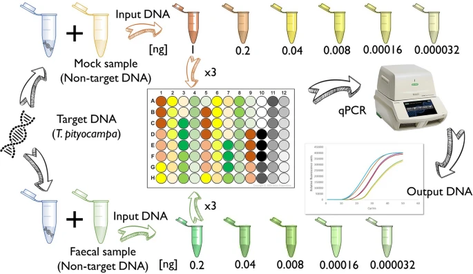

Overview of the experimental workflow for the quantitative assessment of qPCR.

[Full size image](https://www.nature.com/articles/s41598-022-06195-7/figures/1)

For the experiment, we tested (1) 29 mock sample mixtures, i.e., fresh DNA from *T. pityocampa* (*C*+) mixed with DNA of other moths (*C−*) and (2) 35 faecal sample mixtures, mixed DNA from fresh *T. pityocampa* (*C*+) and bat faeces without *T. pityocampa* (*Th*<sub>*out*</sub>−) (Fig. 1). In faecal mixtures, *T. pityocampa* DNA concentration of 1 ng/µL was not used due to problems in maintaining molarity values. The amplification process was carried out following the same qPCR protocol described above. Besides, we also constructed standard curves in triplicate using a five-fold dilution series of targeted templates, from 3.3 × 10<sup>6</sup> to 5.2 × 10<sup>10</sup> copies per μL, to predict the abundance of target DNA present in tested samples.

### Data analysis

All the statistical analyses were carried out in R Studio v. 1.4.1103 and R v.4.0.3.<sup>46</sup>. We conducted further analysis for each of the following questions:

#### The effect of replication effort on detection probabilities

As described by Ref.<sup>27</sup>, an increase in the PCR replication effort leads to an increased likelihood of detecting a target present in the sample. Accordingly, we aimed to evaluate the detection probabilities over the three replicates, for which we used the following equation for each of the replicates:

$${\text{D}}/\left( {{\text{D}} + {\text{ND}}} \right),$$

where D is the number of detections and ND is the number of non-detections.

#### The relationship between DNA quantity and detection probability by cPCR and qPCR

We should expect a higher detection rate in those samples with a higher target DNA concentration. Hence, we examined if there is a relationship between the average DNA abundance estimated from triplicates of *Th*+ samples by qPCR and the detection rates by each PCR assay over the three replicates, for which we fitted logistic regression models (quasi-binomial family) using *glm* function of the *stats* package in R<sup>46</sup>.

#### The relationship between input and output DNA concentrations

We tested whether the input DNA concentrations correlated with the average concentrations estimated by triplicated samples in both mock and faecal samples and determined our qPCR technique’s accuracy to predict target DNA concentrations. For that, we compared abundances yielded by qPCR against the expected DNA concentrations. Ideally, we should expect a positive correlation with a slope near 1. Hence, we initially fitted a linear regression model, but the residual spread increased along with the explanatory variable, which violated the homogeneity of variance assumption of our linear regressions. Therefore, we fitted a generalised least squares (GLS) model with a combined variance structure using the *varComb* function of the *nlme* package<sup>47</sup>, allowing an increase in the residual spread for larger input DNA concentrations as well as a different spread per sample type (mock or faecal). Afterwards, we carried out a likelihood ratio test for the fixed component selection, comparing nested models with three possible explanatory variables: run, sample type and input DNA. The test indicated that neither run nor sample type were important variables affecting the yielded DNA by qPCR. Therefore, the final model only included input DNA as an explanatory variable. We plotted all the models using the *ggplot2* package<sup>48</sup>.